# Domain-Driven Design

- Евгений Сорокин
- Андрей Морозов
- Кирилл Корняков

Ноябрь 2015

# Содержание

- Введение
- Варианты DDD-архитектуры
- Слои и их отношения
- Преимущества DDD

# Что является самым ценным в системе?

- UX / GUI
- Современные технологии
- Качественный код
- Модель предметной области
- Грамотная архитектура

# Eric Evans: Domain-Driven Desing

[figure not shown]

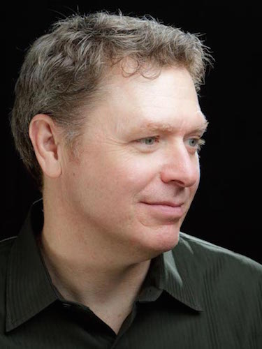

- Общий язык
- Выделенный домен

# Необходимые условия

- Нетривиальный домен
- Команда имеет опыт с ООП/ООД
- Имеется доступ к экспертам предметной области
- Вы используете итеративный процесс

# Основные идеи

- Помещение основного фокуса проекта на домен и его логику
- Интенсивное взаимодействие между командой и экспертами предметной области
- Построение сложных дизайнов на основе модели домена
- Итеративное улучшение модели
- Архитектура не зависит от технологии

# Layered Architecture

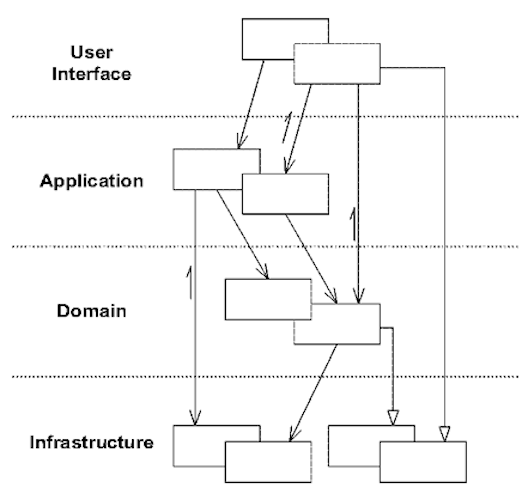

# Layered Architecture

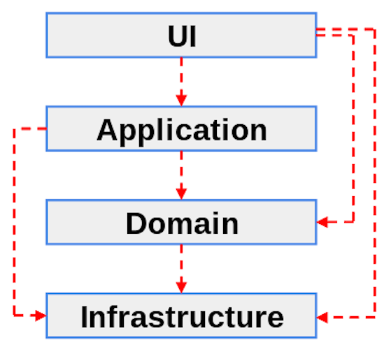

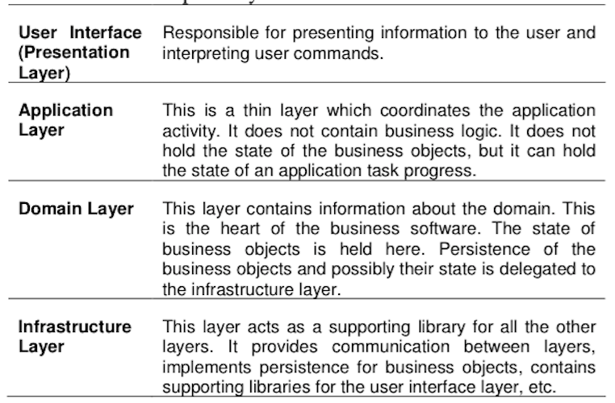

# Dependency Inversion

```java
public class Copy{
    void copy(File f, Printer p){
        while(!f.eof()){
            p.write(f.read());
    }
}
```

```java
public class Copy{
    void copy(IReader r, IWriter w){
        while(!r.end()){
            w.write(r.read());
    }
}
```

# Improved Architecture

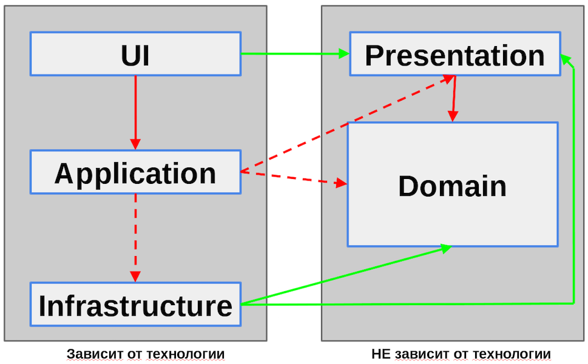

# Elements of DDD

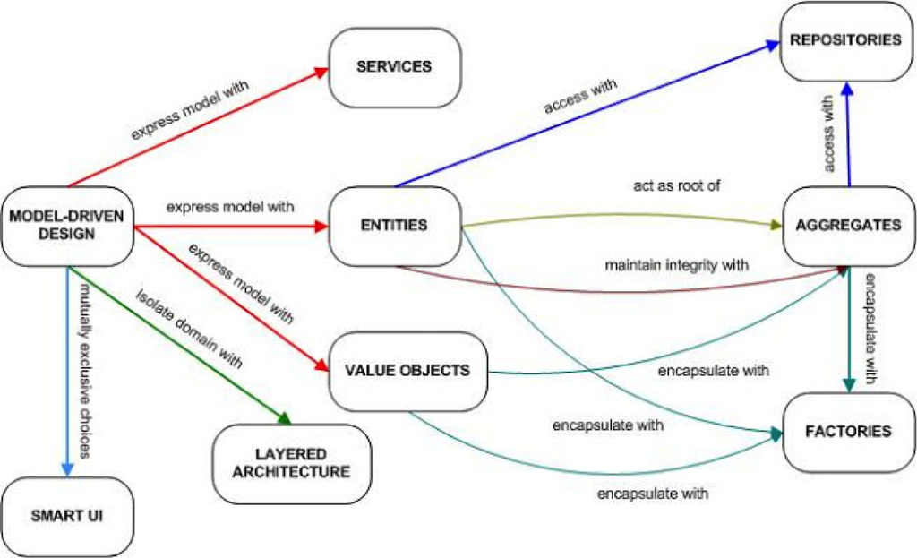

# Слой Domain

**Ответственность**

- Представляет концепцию бизнеса
- Инкапсулирует бизнес-логику и знания предметной области

**Типичные классы**

- Entities, Value Objects, Repositories, Factories, Services

**Связь с другими слоями**

- Domain используется в Presentation

# Слой Presentation

**Ответственность**

- Собирает ввод от пользователя из GUI
- Управляет UI views
- Транслирует объекты Domain в презентационные объекты

**Типичные классы**

- Presenters, Controllers, Translators, Интерфейсы для UI

# Слой Infrastructure

**Ответственность**

- Сохранение, ORM, Кэширование
- Взаимодействие с внешними сервисами

**Типичные классы**

- Adapters, Translators, Service Agents, Facades, O/R Mappers

**Связь с другими слоями**

- Реализует интерфейсы, объявленные в Domain и Presentation

# Слой UI

**Ответственность**

- Показать информацию пользователю
- Реализовать интерфейсы, объявленные в слое Presentation
- Вызвать Application для создания объектов presenters и сделать инъекцию views

**Типичные классы**

- Web pages, Win Forms, User Controls

**Связь с другими слоями**

- Реализует интерфейсы, объявленные в Presentation
- Вызывает Application для создания Presenters

# Слой Application

**Ответственность**

- Создает объекты Presentation, делает инъекцию UI и Infrastructure
- Создает объекты Domain и делает инъекцию Infrastructure

**Типичные классы**

- ApplicationProfile, PresenterFactory

**Связь с другими слоями**

- Создает объекты Presentation, Domain и Infrastructure

# Preserving Model Integrity

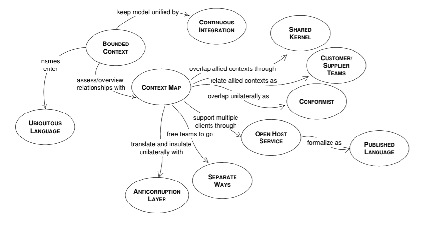

# Anticorruption Layer

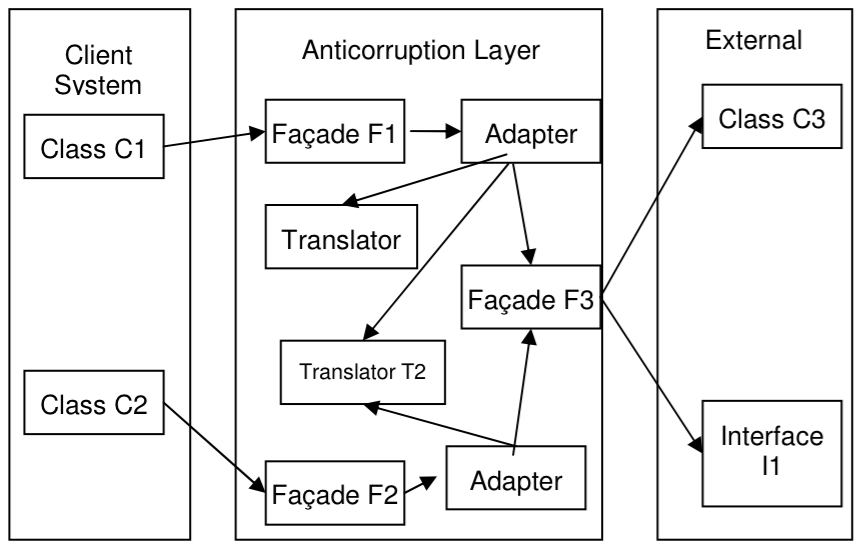

# Что дает DDD

- Чистый и правильно спроектированный домен
- Инкапсуляцию доменной логики
- Понимание кода

# Customer Tests

[figure not shown]

# Контрольные вопросы

1. Понятие Domain, Model. Назначение DDD.
2. Необходимые условия для применения DDD.
3. Нарисовать диаграмму DDD (“улучшенная” слоистая архитектура).
4. Назначение сборки Application.
5. Назначение Infrastructure, способ стыковки с Domain.

# Спасибо!

Вопросы?